# Classification

Author

JACE HIGA!

Published

February 24, 2025

**Abstract:**

This is a technical blog post of **both** an HTML file *and* [.qmd file](https://raw.githubusercontent.com/cd-public/D505/refs/heads/master/hws/src/classify.qmd) hosted on GitHub pages.

# 0. Quarto Type-setting

- This document is rendered with Quarto, and configured to embed an images using the `embed-resources` option in the header.
- If you wish to use a similar header, here’s is the format specification for this document:

```
format:
  html:
    embed-resources: true
```

# 1. Setup

**Step Up Code:**

```r
sh <- suppressPackageStartupMessages
sh(library(tidyverse))
sh(library(caret))
sh(library(naivebayes))
wine <- readRDS(gzcon(url("https://github.com/cd-public/D505/raw/master/dat/pinot.rds")))
```

# 2. Logistic Concepts

Why do we call it Logistic Regression even though we are using the technique for classification? > TODO: *It is because the basis of it comes from using linear combinations of our chosen features to help in modeling relationships in our data. However, it also uses the logistic function to also handle categorical outcomes which allows us to be able to classify.*

# 3. Modeling

1. An 80-20 train-test split.
2. Three features engineered from the description
3. 5-fold cross validation.

```r
library(tidytext)
wine_desc <- wine %>%
  filter(province == "Marlborough") %>%
  unnest_tokens(word, description) %>%
  anti_join(stop_words) %>%
  count(word) %>%
  arrange(desc(n))
```

```r
library(SnowballC)
word <- wine_desc %>%
  mutate(word = wordStem(word))
```

```r
wino <- wine %>%
  mutate(drink = str_detect(description, "drink")) %>%
  mutate(cherri = str_detect(description, "cherri")) %>%
  mutate(fruit = str_detect(description, "fruit")) %>%
  select(-description)
```

```r
set.seed(5)

wine_index <- createDataPartition(wino$province, p = 0.8, list = FALSE)
train <- wino[wine_index, ]
test <- wino[-wine_index, ]

train$province <- factor(train$province)
test$province <- factor(test$province, levels = levels(train$province))
```

```r
train_control <- trainControl(method = "cv", number = 5)

get_fit <- function(train) {
  train(province ~ .,
        data = train,
        trControl = train_control,
        method = "multinom",
        maxit = 5)}

fit <- get_fit(train)
```

```r
fit
```

```
Penalized Multinomial Regression

6707 samples
   7 predictor
   6 classes: 'Burgundy', 'California', 'Casablanca_Valley', 'Marlborough', 'New_York', 'Oregon'

No pre-processing
Resampling: Cross-Validated (5 fold)
Summary of sample sizes: 5367, 5366, 5365, 5365, 5365
Resampling results across tuning parameters:

  decay  Accuracy   Kappa
  0e+00  0.4331286  0.007801769
  1e-04  0.4331286  0.007801769
  1e-01  0.4331286  0.007801769

Accuracy was used to select the optimal model using the largest value.
The final value used for the model was decay = 0.1.
```

# 4. Binary vs Other Classification

What is the difference between determining some form of classification through logistic regression versus methods like $K$-NN and Naive Bayes which performed classifications.

> TODO: *The biggest difference is that regression is able to weigh the features, in our case descriptive words, based on how often they appear.*

# 5. ROC Curves

We can display an ROC for the model to explain your model’s quality.

```r
desc_to_words <- function(df, omits) {
  df %>%
    unnest_tokens(word, description) %>%
    anti_join(stop_words) %>% # get rid of stop words
    filter(!(word %in% omits))
}

words_to_stems <- function(df) {
  df %>%
    mutate(word = wordStem(word))
}

filter_by_count <- function(df, j) {
  df %>%
    count(id, word) %>%
    group_by(id) %>% mutate(exists = (n>0)) %>% ungroup %>%
    group_by(word) %>%
    mutate(total = sum(n)) %>%
    filter(total > j)
}

pivoter <- function(words, df) {
  words %>%
    pivot_wider(id_cols = id, names_from = word, values_from = exists, values_fill = list(exists=0)) %>%
    right_join(select(df,id,province)) %>%
    drop_na() %>%
    select(-id)
}
```

```r
wine_words <- function(df, j, stem) {

  words <- desc_to_words(df, c("drink","cherri","fruit"))

  if (stem) {
    words <- words_to_stems(words)
  }

  words <- filter_by_count(words, j)

  pivoter(words, df)
}
```

```r
# You can find a tutorial on ROC curves here: https://towardsdatascience.com/understanding-auc-roc-curve-68b2303cc9c5
```

```r
winor <- wine_words(wine, 1000, T) %>%
           mutate(marlborough = as.factor(province == "Marlborough")) %>%
           select(-province)
wine_index <- createDataPartition(winor$marlborough, p = 0.80, list = FALSE)
train <- winor[wine_index, ]
test <- winor[-wine_index, ]



fit <- train(marlborough ~ .,
             data = train,
             trControl = train_control,
             method = "glm",
             family = "binomial")
```

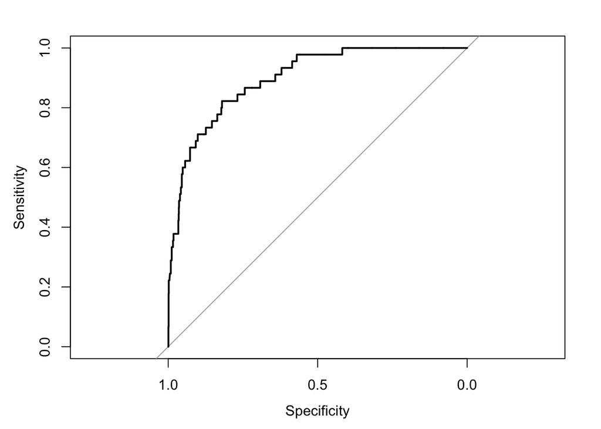

```r
library(pROC)
prob <- predict(fit, newdata = test, type = "prob")[,2]
myRoc <- roc(test$marlborough, prob)
plot(myRoc)
```

```r
auc(myRoc)
```

```
Area under the curve: 0.897
```